# Question

An adventurer, crossing a vast (flat) desert, approaches a distant monument. When the adventurer first notices the monument, the viewing angle (the [angle of elevation](https://www.khanacademy.org/math/geometry/hs-geo-trig/hs-geo-modeling-with-right-triangles/a/angles-of-elevation-and-depression) to the top of the monument) is 0.39 radians.

The adventurer walks toward the monument, getting 1700 meters closer; the viewing angle increases to 1.46 radians.

How tall is the monument (in meters)?

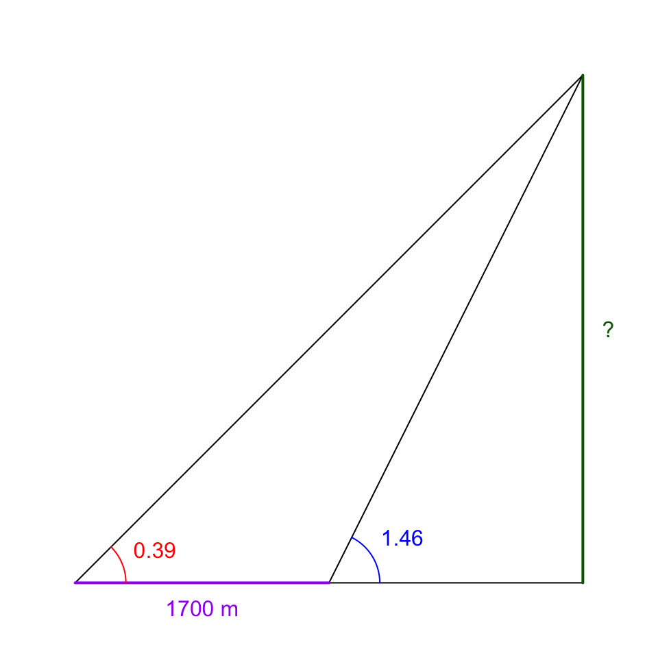

(Figure not drawn to scale.)

PLEASE ROUND YOUR ANSWER TO 2 [SIGNIFICANT FIGURES](https://en.wikipedia.org/wiki/Significant_figures).

# Solution

Below are two methods. The first uses long decimal representations to somewhat simplify the algebra. The second method abstracts the problem further to derive a formula.

## Long decimals

First, label some unknowns with variables.

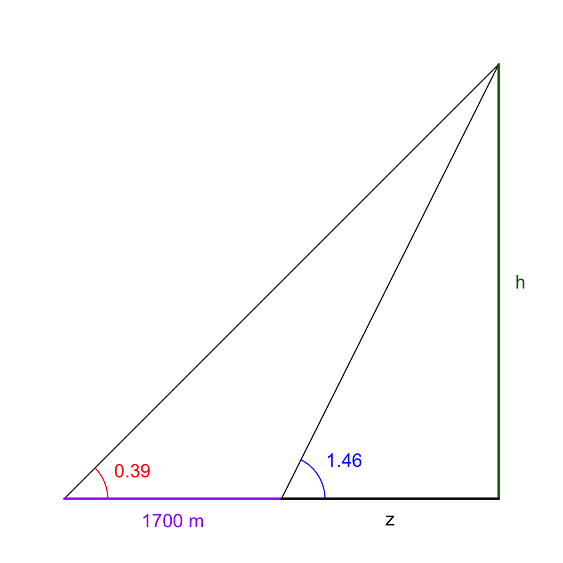

Write a system of equations.

$$\tan(0.39) =
\frac{h}{1700+z}$$

$$\tan(1.46) = \frac{h}{z}$$

Evaluate decimal approximations.

$$0.4110549 =
\frac{h}{1700+z}$$

$$8.9886076 = \frac{h}{z}$$

Isolate (solve for) $z$ in the second equation by multiplying both sides by $z$ and dividing both sides by 8.9886076. Remember, dividing by 8.9886076 is equivalent to multiplying by $\frac{1}{8.9886076}$, which is equivalent to multiplying by $0.1112519$.

$$z ~=~ \frac{h}{8.9886076}$$

$$z ~=~ \frac{1}{8.9886076} h$$

$$z ~=~ 0.1112519 h$$

Substitute $0.1112519 h$ for $z$ in the first equation of the system.

$$0.4110549 = \frac{h}{1700+0.1112519
h}$$

Multiply both sides by the denominator.

$$0.4110549\cdot \left(1700+0.1112519
h\right) = h$$
Distribute.

$$698.7933558+0.0457307 h= h$$

Subtract $0.0457307 h$ from both sides.

$$698.7933558= h-0.0457307 h$$

Simplify the difference by combining like terms.

$$698.7933558= 0.9542693 h$$

Divide both sides by 0.9542693.

$$732.2810479= h$$

Round to two significant figures.

$$h = 730$$

## Further abstraction do derive formula

Rewrite the problem using only variables.

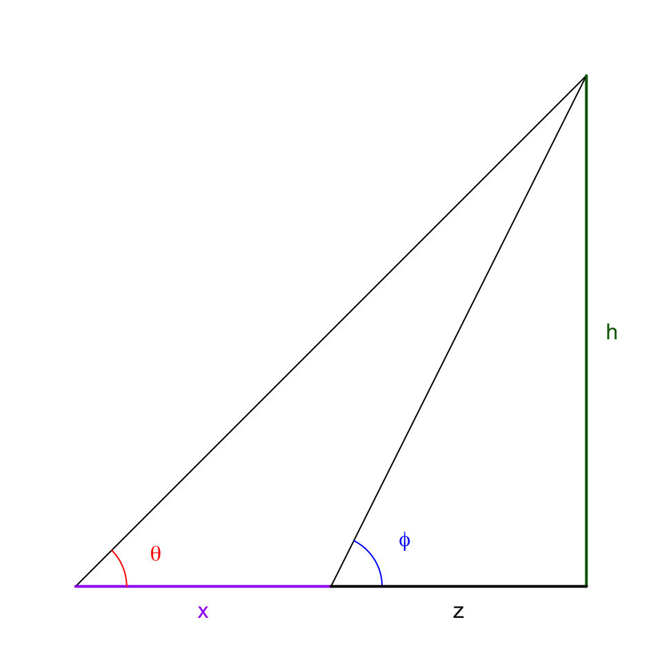

Knowns: $x$, $\theta$, $\phi$

Unknowns: $z$, $h$

Write the system of equations.

$$\tan(\theta) =
\frac{h}{x+z}$$

$$\tan(\phi) = \frac{h}{z}$$

Solve second equation for $z$.

$$z = \frac{h}{\tan(\phi)}$$

Substitute into first equation of system.
$$\tan(\theta) =
\frac{h}{x+\frac{h}{\tan(\phi)}}$$

Multiply both sides by the denominator.

$$\tan(\theta)x +
\frac{\tan(\theta)}{\tan(\phi)}h ~=~ h$$

Multiply by $\tan(\phi)$ to get ride of denominators.

$$\tan(\theta)\tan(\phi)x + \tan(\theta)h
~=~ \tan(\phi)h$$

Subtract $\tan(\theta)h$ from both sides.

$$\tan(\theta)\tan(\phi)x ~=~ \tan(\phi)h
- \tan(\theta)h$$

Factor out $h$.

$$\tan(\theta)\tan(\phi)x ~=~
\big(\tan(\phi) - \tan(\theta)\big)h$$

Solve for $h$.

$$h =
\frac{\tan(\theta)\tan(\phi)x}{\tan(\phi) - \tan(\theta)}$$

If you plug in the known values, you should be able to get $h$.

$$h = 732.2810479$$

Round to 2 significant digits.

$$h = 730$$

# Meta-information

extype: num exsolution: 730 exname: approaching_height